# Clone ETFs

Adrian D. Garcia

August 2020

# Getting Started

```r
library(tidyverse) #For Data Analysis
library(lubridate) #For working with dates
library(DT) #For visualizing tables
```

## Data

First, I pulled in the mutual fund data from Morningstar Direct. (I combined it using “combine_files.r”). There were 25,264 rows and 43 columns. I also pulled in ETF data from Morninstar. There were 2,420 rows and 44 columns. Data was pulled from Morningstar Direct on Aug. 18, 2020.

I combine these two data sets to create a dataset of mutual funds and ETFs, 27,684 rows, 44 columns.

I added a column that shows if the data came from the ETF or MUTUAL FUND dataset. I also changed all column names to replace spaces with periods.

I follow the same process as above to upload data that has assset and flow information for mutual funds and ETFs.

```r
MFs <- read_csv("~/Data/Clone_ETFs/Mutual_Funds/MS_MFS_081820_Full.csv",
                 guess_max = 25000) %>%
  mutate(TYPE = "MUTUAL FUND")


ETFs <- read_csv("~/Data/Clone_ETFs/ETFs/MS_ETFS_082020_Full.csv",
                 guess_max = 25000) %>%
  mutate(TYPE = "ETF")

Data <- full_join(ETFs, MFs) %>%
  rename_all(make.names)

###

MFs_Assets <- read_csv("~/Data/Clone_ETFs/Mutual_Funds/MS_MFS_082020_Full.csv",
                 guess_max = 25000) %>%
  mutate(TYPE = "MUTUAL FUND")


ETFs_Assets <- read_csv("~/Data/Clone_ETFs/ETFs/MS_ETFSFLOW_082020_Full.csv",
                 guess_max = 25000) %>%
  mutate(TYPE = "ETF")

Data_Assets <- full_join(ETFs_Assets, MFs_Assets) %>%
  rename_all(make.names)
```

## Adjustment

I create a new column “Name.Mod” that removes the last word from the fund name. This is where the share class type typically is located.

And in the cases below I replace the name of the firm with either its alternate version in Morningstar or combined firms that are linked operationally.

Finally, I remove funds of funds.

23,158 funds remain.

```r
Data <- Data %>%
  mutate(
    Name.Mod = str_replace(Name, "\\s\\w*(™)?$", ""),
    Name.Mod = case_when(
      Name.Mod == "Fidelity® New" ~ "Fidelity® New Millennium",
      TRUE ~ as.character(Name.Mod)
      ),
    Firm.Name = case_when(
      Firm.Name == "SPDR State Street Global Advisors" ~ "State Street Global Advisors",
      Firm.Name == "iShares" ~ "iShares/BlackRock",
      Firm.Name == "BlackRock" ~ "iShares/BlackRock",
      Firm.Name == "Calvert Research Management" ~ "Calvert/Eaton Vance",
      Firm.Name == "Eaton Vance" ~ "Calvert/Eaton Vance",
      Firm.Name == "Nuveen" ~ "Nuveen/TIAA Investments",
      Firm.Name == "TIAA" ~ "Nuveen/TIAA Investments",
      TRUE ~ as.character(Firm.Name)
      )) %>%
      select(Name, Name.Mod, TYPE, everything()) %>%
  filter(
    Fund.of..Funds != "Yes"
  )

##

Data_Assets <- Data_Assets %>%
  mutate(
    Name.Mod = str_replace(Name, "\\s\\w*(™)?$", ""),
    Name.Mod = case_when(
      Name.Mod == "Fidelity® New" ~ "Fidelity® New Millennium",
      TRUE ~ as.character(Name.Mod)
      ),
    Firm.Name = case_when(
      Firm.Name == "SPDR State Street Global Advisors" ~ "State Street Global Advisors",
      Firm.Name == "iShares" ~ "iShares/BlackRock",
      Firm.Name == "BlackRock" ~ "iShares/BlackRock",
      Firm.Name == "Calvert Research Management" ~ "Calvert/Eaton Vance",
      Firm.Name == "Eaton Vance" ~ "Calvert/Eaton Vance",
      Firm.Name == "Nuveen" ~ "Nuveen/TIAA Investments",
      Firm.Name == "TIAA" ~ "Nuveen/TIAA Investments",
      TRUE ~ as.character(Firm.Name)
      )) %>%
      select(Name, Name.Mod, TYPE, everything())
```

## Finding matches

I would like to take the full dataset created above and find cases where mutual funds and etfs match at the same shop. The easiest, most accurate way I’ve found to do this is to look at the following two combinations:

- A fund’s strategy and its branding name (366 funds)
- A fund’s strategy and it’s firm name (369 funds)

I can cross reference these individual dataframes by each other to come up with 408 funds.

A setback to this approach is that there are 406 rows without a strategy name. I isolated these funds and compared them to each other by their fund name (minus the last word which is usually the shareclass type). I found no matches.

```r
#We decided not to use this

# Management <- Data %>%
#   group_by(Strategy.Name, Management.Company, TYPE) %>%
#   summarise(COUNT = n()) %>%
#   pivot_wider(names_from = TYPE, values_from = COUNT) %>%
#   group_by(Strategy.Name, Management.Company)
#
# Mgt_Matches <- Management %>%
#   filter(!is.na(`MUTUAL FUND`) &
#            !is.na(ETF))
#
# Mgt_Matches_df <- Data %>%
#   filter(Strategy.Name %in% Mgt_Matches$Strategy.Name &
#            !is.na(Management.Company))

###

Brand <- Data %>%
  group_by(Strategy.Name, Branding.Name, TYPE) %>%
  summarise(COUNT = n()) %>%
  pivot_wider(names_from = TYPE, values_from = COUNT) %>%
  group_by(Strategy.Name, Branding.Name)

Brand_Matches <- Brand %>%
  filter(!is.na(`MUTUAL FUND`) &
           !is.na(ETF))

Brand_df <- Data %>%
  filter(Strategy.Name %in% Brand_Matches$Strategy.Name &
           Branding.Name %in% Brand_Matches$Branding.Name &
           !is.na(Branding.Name) &
           !is.na(Strategy.Name))

###

Firm <- Data %>%
  group_by(Strategy.Name, Firm.Name, TYPE) %>%
  summarise(COUNT = n()) %>%
  pivot_wider(names_from = TYPE, values_from = COUNT) %>%
  group_by(Strategy.Name, Firm.Name)

Firm_Matches <- Firm %>%
  filter(!is.na(`MUTUAL FUND`) &
           !is.na(ETF))

Firm_df <- Data %>%
  filter(Strategy.Name %in% Firm_Matches$Strategy.Name &
           Firm.Name %in% Firm_Matches$Firm.Name &
           !is.na(Firm.Name) &
           !is.na(Strategy.Name))

Combined_matches <- full_join(Brand_df, Firm_df)

# Blanks <- Data %>%
#   filter(is.na(Strategy.Name)) %>%
#   mutate(Name.Mod = str_replace(Name, "\\s\\w*(™)?$", "")) %>%
#   select(Name, Name.Mod, TYPE, everything()) %>%
#   group_by(Name.Mod, TYPE) %>%
#   summarise(COUNT = n()) %>%
#   pivot_wider(names_from = TYPE, values_from = COUNT) %>%
#   filter(!is.na(`MUTUAL FUND`) &
#            !is.na(ETF))
```

|  | Strategy.Name | Firm.Name | ETF | MUTUAL FUND |
| --- | --- | --- | --- | --- |
| 1 | American Century Emerging Markets Equity | Avantis Investors | 1 | 1 |
| 2 | American Century International Equity | Avantis Investors | 1 | 1 |
| 3 | American Century Intl Small Cap Value | Avantis Investors | 1 | 1 |
| 4 | American Century US Equity | Avantis Investors | 1 | 1 |
| 5 | American Century US Small Cap Value | American Century Investments |  | 9 |
| 6 | American Century US Small Cap Value | Avantis Investors | 1 | 1 |
| 7 | Blackrock - Russell 2000 Index | iShares/BlackRock | 1 | 4 |
| 8 | BlackRock International Equity Index | iShares/BlackRock | 1 | 4 |
| 9 | BlackRock MSCI World EX USA Div Lrg Bld | iShares/BlackRock | 1 | 2 |
| 10 | BlackRock S&amp;P 500 Index | iShares/BlackRock | 1 | 6 |

[output cut: 115 more lines]

To reduce the chance that funds were missed either because the strategy is blank or slightly different I can compare funds based on their names (minus the last word where the share class type typically is located).

I come up with 146 funds that match. I can then cross reference that list against the list I created above to add the ones I’m missing. I go from 408 matches to 499 matches.

```r
Names <- Data %>%
  group_by(Name.Mod, TYPE) %>%
  count() %>%
  pivot_wider(names_from = TYPE, values_from = n) %>%
  filter(!is.na(`MUTUAL FUND`)&!is.na(ETF))

Names_df <- Data %>%
  mutate(Name.Mod = str_replace(Name, "\\s\\w*(™)?$", "")) %>%
  filter(Name.Mod %in% Names$Name.Mod)


Combined_matches <- full_join(Combined_matches, Names_df)

write_csv(Combined_matches, "~/Data/Clone_ETFs/results/Matched_Data.csv")
```

|  | Strategy.Name | Firm.Name | ETF | MUTUAL FUND |
| --- | --- | --- | --- | --- |
| 1 | American Century Emerging Markets Equity | Avantis Investors | 1 | 1 |
| 2 | American Century International Equity | Avantis Investors | 1 | 1 |
| 3 | American Century Intl Small Cap Value | Avantis Investors | 1 | 1 |
| 4 | American Century US Equity | Avantis Investors | 1 | 1 |
| 5 | American Century US Small Cap Value | American Century Investments |  | 9 |
| 6 | American Century US Small Cap Value | Avantis Investors | 1 | 1 |
| 7 | American Century US Systematic Lg Cp Cor | American Century Investments |  | 9 |
| 8 | Anfield Multisector Bond | Affinity | 1 |  |
| 9 | Anfield Universal Fixed Income | Anfield |  | 3 |
| 10 | Blackrock - Russell 2000 Index | iShares/BlackRock | 1 | 4 |

[output cut: 146 more lines]

# ETFs

## Overview

From the data above I find 126 ETFs that are likely clones or near clones of existing mutual funds.

```r
ETF_df <- Combined_matches %>%
  filter(TYPE == "ETF")

MF_df <- Combined_matches %>%
  filter(TYPE != "ETF")

datatable(ETF_df)
```

|  | Name | Name.Mod | TYPE | Firm.Name | Branding.Name | Management.Company | Ticker | ISIN | Global.Broad..Category.Group | Global..Category | Morningstar.Category | Morningstar..Institutional.Category | US.Category.Group | Oldest..Share.Class | Index..Fund | Fund.of..Funds | Share.Class.Type | Most.Recent.Category..Peer.Group.Name | Strategy.Name | StrategyId | Clean.Share...Service.Fee.Arrangement | Annual.Report.Adjusted.Expense.Ratio | Prospectus.Adjusted.Expense.Ratio | Inception..Date | Obsolete..Date | Obsolete..Type | Management..Fee | Annual.Report..Net.Expense..Ratio | Net.Assets...share.class..Monthly...2020.07..USD | … |
| --- | --- | --- | --- | --- | --- | --- | --- | --- | --- | --- | --- | --- | --- | --- | --- | --- | --- | --- | --- | --- | --- | --- | --- | --- | --- | --- | --- | --- | --- | --- |
| 1 | Avantis™ Emerging Markets Equity ETF | Avantis™ Emerging Markets Equity | ETF | Avantis Investors | American Century | American Century Investment Management, Inc | AVEM |  | Equity | Global Emerging Markets Equity | US Fund Diversified Emerging Mkts | Diversified Emerging Markets | International Equity | Yes | No | No |  | US Fund Diversified Emerging Mkts | American Century Emerging Markets Equity | STUSA076J6 | Semi-bundled |  | 0.33 | 2019-09-17 |  |  | 0.33 |  | 240250587 | … |
| 2 | Avantis™ International Equity ETF | Avantis™ International Equity | ETF | Avantis Investors | American Century | American Century Investment Management, Inc | AVDE |  | Equity | Global Equity Large Cap | US Fund Foreign Large Blend | Foreign Large Core | International Equity | Yes | No | No |  | US Fund Foreign Large Blend | American Century International Equity | STUSA076J2 | Semi-bundled |  | 0.23 | 2019-09-24 |  |  | 0.23 |  | 311498259 | … |
| 3 | Avantis™ International Small Cap Val ETF | Avantis™ International Small Cap Val | ETF | Avantis Investors | American Century | American Century Investment Management, Inc | AVDV |  | Equity | Global Equity Mid/Small Cap | US Fund Foreign Small/Mid Value | Foreign Small/Mid Value | International Equity | Yes | No | No |  | US Fund Foreign Small/Mid Value | American Century Intl Small Cap Value | STUSA076J3 | Semi-bundled |  | 0.36 | 2019-09-24 |  |  | 0.36 |  | 166511229 | … |
| 4 | Avantis™ U.S. Equity ETF | Avantis™ U.S. Equity | ETF | Avantis Investors | American Century | American Century Investment Management, Inc | AVUS |  | Equity | US Equity Large Cap Blend | US Fund Large Blend | Large Core | U.S. Equity | Yes | No | No |  | US Fund Large Blend | American Century US Equity | STUSA076J4 | Semi-bundled |  | 0.15 | 2019-09-24 |  |  | 0.15 |  | 396828382 | … |
| 5 | Avantis™ U.S. Small Cap Value ETF | Avantis™ U.S. Small Cap Value | ETF | Avantis Investors | American Century | American Century Investment Management, Inc | AVUV |  | Equity | US Equity Small Cap | US Fund Small Value | Small Core Value | U.S. Equity | Yes | No | No |  | US Fund Small Value | American Century US Small Cap Value | STUSA076J5 | Semi-bundled |  | 0.25 | 2019-09-24 |  |  | 0.25 |  | 296418844 | … |
| 6 | CBOE VestS&amp;P500 Div Arstcrts Tgt Inc ETF | CBOE VestS&amp;P500 Div Arstcrts Tgt Inc | ETF | CBOE Vest | vest | CBOE Vest Financial LLC | KNG |  | Equity | US Equity Large Cap Blend | US Fund Large Blend | Large Core | U.S. Equity | Yes | Yes | No |  | US Fund Large Blend | CBOE Vest S&amp;P 500 Dv Arst Trgt Inc | STUSA05TEJ | Semi-bundled | 0.75 | 0.75 | 2018-03-26 |  |  | 0.75 | 0.75 | 58642529 | … |
| 7 | Davis Select Financial ETF | Davis Select Financial | ETF | Davis ETFs | Davis | Davis Selected Advisers LP | DFNL |  | Equity | Financials Sector Equity | US Fund Financial | Domestic Financial | Sector Equity | Yes | No | No |  | US Fund Financial | Davis Financial Securities | STUSA04EA5 | Semi-bundled | 0.64 | 0.64 | 2017-01-11 |  |  | 0.55 | 0.64 | 130172577 | … |
| 8 | Davis Select International ETF | Davis Select International | ETF | Davis ETFs | Davis | Davis Selected Advisers LP | DINT |  | Equity | Global Equity Large Cap | US Fund Foreign Large Blend | Foreign Large Core | International Equity | Yes | No | No |  | US Fund Foreign Large Blend | Davis International Equity | STUSA04GLG | Semi-bundled | 0.68 | 0.68 | 2018-03-01 |  |  | 0.55 | 0.68 | 212610583 | … |
| 9 | Davis Select Worldwide ETF | Davis Select Worldwide | ETF | Davis ETFs | Davis | Davis Selected Advisers LP | DWLD |  | Equity | Global Equity Large Cap | US Fund World Large Stock | World Large Core | International Equity | Yes | No | No |  | US Fund World Large Stock | Davis Global Equity | STUSA04FZ7 | Semi-bundled | 0.63 | 0.63 | 2017-01-11 |  |  | 0.55 | 0.63 | 272154684 | … |
| 10 | Eaton Vance Global Income Builder NS™ | Eaton Vance Global Income Builder | ETF | Calvert/Eaton Vance | Eaton Vance | Eaton Vance Management | EVGBC |  | Allocation | Moderate Allocation | US Fund World Allocation | Multi-Asset Income | Allocation | Yes | No | No |  | US Fund World Allocation | Eaton Vance Global Income Builder | STUSA0575T | Semi-bundled | 0.88 | 0.84 | 2016-03-30 |  |  | 0.7 | 0.88 | 5931657 | … |

[output cut: 117 more lines]

```r
datatable(ETF_df)
```

|  | Name | Name.Mod | TYPE | Firm.Name | Branding.Name | Management.Company | Ticker | ISIN | Global.Broad..Category.Group | Global..Category | Morningstar.Category | Morningstar..Institutional.Category | US.Category.Group | Oldest..Share.Class | Index..Fund | Fund.of..Funds | Share.Class.Type | Most.Recent.Category..Peer.Group.Name | Strategy.Name | StrategyId | Clean.Share...Service.Fee.Arrangement | Annual.Report.Adjusted.Expense.Ratio | Prospectus.Adjusted.Expense.Ratio | Inception..Date | Obsolete..Date | Obsolete..Type | Management..Fee | Annual.Report..Net.Expense..Ratio | Net.Assets...share.class..Monthly...2020.07..USD | … |
| --- | --- | --- | --- | --- | --- | --- | --- | --- | --- | --- | --- | --- | --- | --- | --- | --- | --- | --- | --- | --- | --- | --- | --- | --- | --- | --- | --- | --- | --- | --- |
| 1 | Avantis™ Emerging Markets Equity ETF | Avantis™ Emerging Markets Equity | ETF | Avantis Investors | American Century | American Century Investment Management, Inc | AVEM |  | Equity | Global Emerging Markets Equity | US Fund Diversified Emerging Mkts | Diversified Emerging Markets | International Equity | Yes | No | No |  | US Fund Diversified Emerging Mkts | American Century Emerging Markets Equity | STUSA076J6 | Semi-bundled |  | 0.33 | 2019-09-17 |  |  | 0.33 |  | 240250587 | … |
| 2 | Avantis™ International Equity ETF | Avantis™ International Equity | ETF | Avantis Investors | American Century | American Century Investment Management, Inc | AVDE |  | Equity | Global Equity Large Cap | US Fund Foreign Large Blend | Foreign Large Core | International Equity | Yes | No | No |  | US Fund Foreign Large Blend | American Century International Equity | STUSA076J2 | Semi-bundled |  | 0.23 | 2019-09-24 |  |  | 0.23 |  | 311498259 | … |
| 3 | Avantis™ International Small Cap Val ETF | Avantis™ International Small Cap Val | ETF | Avantis Investors | American Century | American Century Investment Management, Inc | AVDV |  | Equity | Global Equity Mid/Small Cap | US Fund Foreign Small/Mid Value | Foreign Small/Mid Value | International Equity | Yes | No | No |  | US Fund Foreign Small/Mid Value | American Century Intl Small Cap Value | STUSA076J3 | Semi-bundled |  | 0.36 | 2019-09-24 |  |  | 0.36 |  | 166511229 | … |
| 4 | Avantis™ U.S. Equity ETF | Avantis™ U.S. Equity | ETF | Avantis Investors | American Century | American Century Investment Management, Inc | AVUS |  | Equity | US Equity Large Cap Blend | US Fund Large Blend | Large Core | U.S. Equity | Yes | No | No |  | US Fund Large Blend | American Century US Equity | STUSA076J4 | Semi-bundled |  | 0.15 | 2019-09-24 |  |  | 0.15 |  | 396828382 | … |
| 5 | Avantis™ U.S. Small Cap Value ETF | Avantis™ U.S. Small Cap Value | ETF | Avantis Investors | American Century | American Century Investment Management, Inc | AVUV |  | Equity | US Equity Small Cap | US Fund Small Value | Small Core Value | U.S. Equity | Yes | No | No |  | US Fund Small Value | American Century US Small Cap Value | STUSA076J5 | Semi-bundled |  | 0.25 | 2019-09-24 |  |  | 0.25 |  | 296418844 | … |
| 6 | CBOE VestS&amp;P500 Div Arstcrts Tgt Inc ETF | CBOE VestS&amp;P500 Div Arstcrts Tgt Inc | ETF | CBOE Vest | vest | CBOE Vest Financial LLC | KNG |  | Equity | US Equity Large Cap Blend | US Fund Large Blend | Large Core | U.S. Equity | Yes | Yes | No |  | US Fund Large Blend | CBOE Vest S&amp;P 500 Dv Arst Trgt Inc | STUSA05TEJ | Semi-bundled | 0.75 | 0.75 | 2018-03-26 |  |  | 0.75 | 0.75 | 58642529 | … |
| 7 | Davis Select Financial ETF | Davis Select Financial | ETF | Davis ETFs | Davis | Davis Selected Advisers LP | DFNL |  | Equity | Financials Sector Equity | US Fund Financial | Domestic Financial | Sector Equity | Yes | No | No |  | US Fund Financial | Davis Financial Securities | STUSA04EA5 | Semi-bundled | 0.64 | 0.64 | 2017-01-11 |  |  | 0.55 | 0.64 | 130172577 | … |
| 8 | Davis Select International ETF | Davis Select International | ETF | Davis ETFs | Davis | Davis Selected Advisers LP | DINT |  | Equity | Global Equity Large Cap | US Fund Foreign Large Blend | Foreign Large Core | International Equity | Yes | No | No |  | US Fund Foreign Large Blend | Davis International Equity | STUSA04GLG | Semi-bundled | 0.68 | 0.68 | 2018-03-01 |  |  | 0.55 | 0.68 | 212610583 | … |
| 9 | Davis Select Worldwide ETF | Davis Select Worldwide | ETF | Davis ETFs | Davis | Davis Selected Advisers LP | DWLD |  | Equity | Global Equity Large Cap | US Fund World Large Stock | World Large Core | International Equity | Yes | No | No |  | US Fund World Large Stock | Davis Global Equity | STUSA04FZ7 | Semi-bundled | 0.63 | 0.63 | 2017-01-11 |  |  | 0.55 | 0.63 | 272154684 | … |
| 10 | Eaton Vance Global Income Builder NS™ | Eaton Vance Global Income Builder | ETF | Calvert/Eaton Vance | Eaton Vance | Eaton Vance Management | EVGBC |  | Allocation | Moderate Allocation | US Fund World Allocation | Multi-Asset Income | Allocation | Yes | No | No |  | US Fund World Allocation | Eaton Vance Global Income Builder | STUSA0575T | Semi-bundled | 0.88 | 0.84 | 2016-03-30 |  |  | 0.7 | 0.88 | 5931657 | … |

[output cut: 117 more lines]

Let’s see which firms have the most.

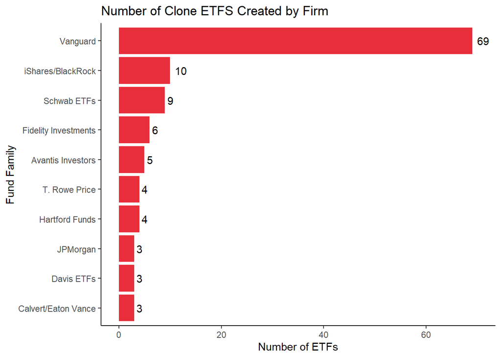

```r
ETF_df %>%
  group_by(Firm.Name) %>%
  count() %>%
  arrange(-n) %>%
  ungroup() %>%
  top_n(10) %>%


ggplot(., mapping = aes(x = reorder(Firm.Name, n), y = n)) +
  geom_bar(stat = "identity", fill = "#e82e3b") +
  coord_flip() +
  scale_y_continuous(limits = c(0, 70)) +
  geom_text(aes(label = n, hjust = -.4)) +
  ggtitle("Number of Clone ETFS Created by Firm") +
  ylab("Number of ETFs") +
  xlab("Fund Family") +
  theme_classic()
```

Let’s see when they were created:

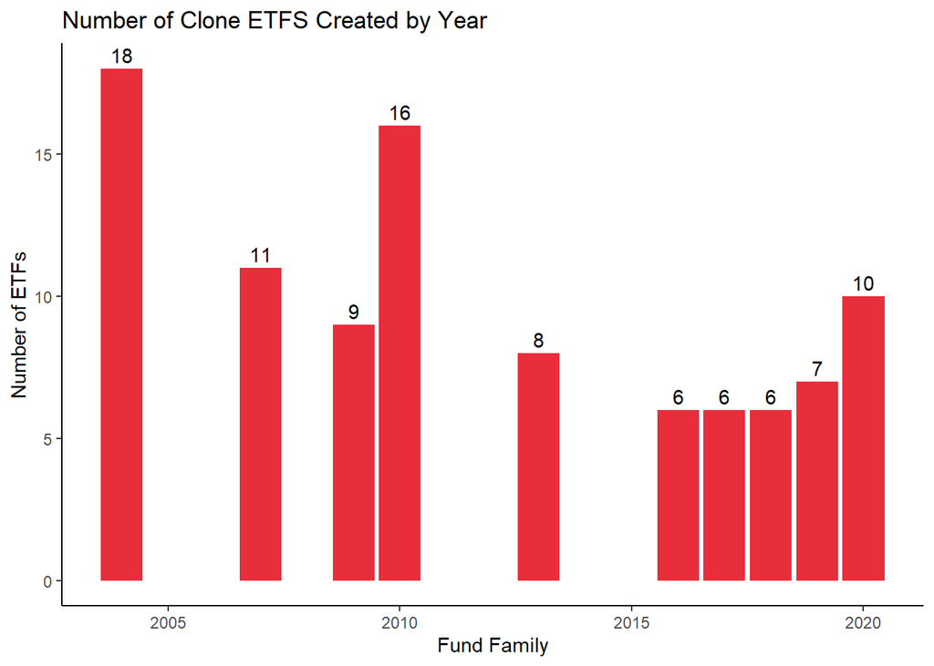

```r
ETF_df %>%
  mutate(
    YEAR = year(Inception..Date)
  ) %>%
  group_by(YEAR) %>%
  count() %>%
  arrange(YEAR) %>%
  ungroup() %>%
  top_n(10) %>%


ggplot(., mapping = aes(x = YEAR, y = n)) +
  geom_bar(stat = "identity", fill = "#e82e3b") +
  geom_text(aes(label = n, vjust = -.4)) +
  ggtitle("Number of Clone ETFS Created by Year") +
  ylab("Number of ETFs") +
  xlab("Fund Family") +
  theme_classic()
```

## ETFs & Mutual Funds

I would like to pair the ETFs we’ve identified with the mutual funds which they are similar. I need to do this in two setps:

- Isolate unique strategy names that have at least one corresponding ETF and MF (441 funds)
- Isolate fund names (Name.Mod) that have at least one corresponding ETF and MF and don’t match one of the funds above (57 funds)

```r
Strat_df <- Combined_matches %>%
  mutate(TYPE2 = TYPE) %>%
  group_by(Name) %>%
  mutate(Count = n()) %>%
  pivot_wider(names_from = TYPE, values_from = Count) %>%
  group_by(Strategy.Name) %>%
  mutate(
    Group = str_c("Strat", group_indices()),
    ETF = sum(ETF, na.rm = TRUE),
    `MUTUAL FUND` = sum(`MUTUAL FUND`, na.rm = TRUE)
    ) %>%
  select(Strategy.Name, Group, Name, Name.Mod, ETF, `MUTUAL FUND`, TYPE2, everything()) %>%
  filter(
    ETF > 0 &
      `MUTUAL FUND` > 0
  )

NameMod_df <- Combined_matches %>%
  mutate(TYPE2 = TYPE) %>%
  group_by(Name) %>%
  mutate(Count = n()) %>%
  pivot_wider(names_from = TYPE, values_from = Count) %>%
  group_by(Name.Mod) %>%
  mutate(
    Group = str_c("Name", group_indices()),
    ETF = sum(ETF, na.rm = TRUE),
    `MUTUAL FUND` = sum(`MUTUAL FUND`, na.rm = TRUE)) %>%
  select(Strategy.Name, Group, Name, Name.Mod, ETF, `MUTUAL FUND`, TYPE2, everything()) %>%
  filter(
    !Name %in% Strat_df$Name
  )

ETF_Pairs <- full_join(NameMod_df, Strat_df)
```

# Assets

## ETFs

Now I want to explore how much assets and inflows these clone ETFs generated compared to their mutual fund counterparts.

I’m looking at ETFs that were launched at least three years ago and in the data (ETF_df) we created above. (101 match)

Then: * Add up outflows first six months of 2020 ** Rest of years calculated by Morningstar * Add up assets in 2017, 2018, 2019 as well as first six months of 2020

```r
ETF_2017 <- Data_Assets %>%
  filter(
    Name %in% ETF_df$Name &
    Inception..Date <= "2017-08-01"
  ) %>%
  mutate(
    Flows_SixMo2020 = rowSums(.[, 11:16], na.rm = TRUE),
    Assets_2017 = rowSums(.[, 18:29], na.rm = TRUE),
    Assets_2018 = rowSums(.[, 30:41], na.rm = TRUE),
    Assets_2019 = rowSums(.[, 42:53], na.rm = TRUE),
    Assets_SixMo2020 = rowSums(.[, 54:59], na.rm = TRUE)) %>%
  select(
    1:6,
    7:10,
    61:65,
    everything()
  )

Sum_ETF2017 <- ETF_2017 %>%
  summarise(
    Flows_2017 = sum(Estimated.Share.Class.Net.Flow..Yearly...Year2017..USD, na.rm = TRUE),
    Flows_2018 = sum(Estimated.Share.Class.Net.Flow..Yearly...Year2018..USD, na.rm = TRUE),
    Flows_2019 = sum(Estimated.Share.Class.Net.Flow..Yearly...Year2019..USD, na.rm = TRUE),
    Flows_SixMo2020 = sum(Flows_SixMo2020),
    Assets_2017 = sum(Assets_2017),
    Assets_2018 = sum(Assets_2018),
    Assets_2019 = sum(Assets_2019),
    Assets_SixMo2020 = sum(Assets_SixMo2020)
  )

write.xlsx(as.data.frame(ETF_2017), file = "C:\\Users\\agarcia\\Documents\\Data\\Clone_ETFs\\results\\assets.xlsx", sheetName = "ETF_Assets",
  col.names = TRUE, row.names = FALSE, append = FALSE)

datatable(Sum_ETF2017)
```

|  | Flows_2017 | Flows_2018 | Flows_2019 | Flows_SixMo2020 | Assets_2017 | Assets_2018 | Assets_2019 | Assets_SixMo2020 |
| --- | --- | --- | --- | --- | --- | --- | --- | --- |
| 1 | 213968254269.31 | 108768931486.72 | 144227470325.28 | 52877391153.47 | 16302985031960 | 19185112736989 | 21374135885372 | 11233485071778 |

```r
MF_Flows <- Data_Assets %>%
  filter(
    Name %in% MF_df$Name
  )

TESTKEY <- ETF_Pairs %>%
  filter(
    Name %in% ETF_2017$Name
  )

MF_2017 <- ETF_Pairs %>%
  filter(
    Group %in% TESTKEY$Group &
    TYPE2 == "MUTUAL FUND"
  )

MF_2017 <- Data_Assets %>%
  filter(
    Name %in% MF_2017$Name,
  ) %>%
  mutate(
    Flows_SixMo2020 = rowSums(.[, 11:16], na.rm = TRUE),
    Assets_2017 = rowSums(.[, 18:29], na.rm = TRUE),
    Assets_2018 = rowSums(.[, 30:41], na.rm = TRUE),
    Assets_2019 = rowSums(.[, 42:53], na.rm = TRUE),
    Assets_SixMo2020 = rowSums(.[, 54:59], na.rm = TRUE)) %>%
  select(
    1:6,
    7:10,
    61:65,
    everything()
  )

write.xlsx(as.data.frame(MF_2017), file = "C:\\Users\\agarcia\\Documents\\Data\\Clone_ETFs\\results\\assets.xlsx", sheetName = "MF_Assets",
  col.names = TRUE, row.names = FALSE, append = TRUE)


Sum_MF2017 <- MF_2017 %>%
  summarise(
    Flows_2017 = sum(Estimated.Share.Class.Net.Flow..Yearly...Year2017..USD, na.rm = TRUE),
    Flows_2018 = sum(Estimated.Share.Class.Net.Flow..Yearly...Year2018..USD, na.rm = TRUE),
    Flows_2019 = sum(Estimated.Share.Class.Net.Flow..Yearly...Year2019..USD, na.rm = TRUE),
    Flows_SixMo2020 = sum(Flows_SixMo2020),
    Assets_2017 = sum(Assets_2017),
    Assets_2018 = sum(Assets_2018),
    Assets_2019 = sum(Assets_2019),
    Assets_SixMo2020 = sum(Assets_SixMo2020)
  )
```